# LITERACY AND 2016 ELECTIONS CANDIDATE PREFERENCE

*May 29, 2019*

`MSDS 2020 DMW Lab 1`

*We would like to thank **Christian Alis** and the **ACCeSs Lab Team** for the **2015 census** and **2016 elections** datasets.*

- Census data was gathered from the Philippine Statistics Authority (PSA) and are stored as xls files which are by country, region, province, and municipality.
- 2016 Election data was scraped from the Comelec website by Chris Alis and are stored as json files by country, region, province, and municipality.

```python
from IPython.display import HTML

HTML('''<script>
  function code_toggle() {
    if (code_shown){
      $('div.input').hide('500');
      $('#toggleButton').val('Show Code')
    } else {
      $('div.input').show('500');
      $('#toggleButton').val('Hide Code')
    }
    code_shown = !code_shown
  }

  $( document ).ready(function(){
    code_shown=false;
    $('div.input').hide()
  });
</script>
<form action="javascript:code_toggle()"><input type="submit" id="toggleButton" value="Show Code"></form>''')
```

## Do you remember the 2016 Philippine Elections?

### The infamous elections where candidates battled furiously during debates, campaigns, and interviews?

[figure not shown]

Source: https://www.rappler.com/nation/politics/elections/2016/131905-phvote-2016-philippine-elections-results-page-features

The code hidden below shows the `extraction, pre-processing and transformation` of the `2016 Election Returns data` and loading it to the database file (`elvotes2016.db`). Runtime will take around 10-15mins.

**NO NEED TO EXECUTE AS THE DB FILE IS ALREADY PROVIDED.** Just make sure the db file is in the same location as this Jupyter notebook.

```python
# # Get all ER file path names from directory
# %%bash --out output
# find /mnt/data/public/elections/nle2016/PHILIPPINES/ -type f -name *.json
```

```python
# # Get region, province, position from file name
# er_files = [[i[47:].split('/'), i] for i in output.split('\n')]

# values = []
# for er in er_files:
#     j = [er[1]]
#     j.extend(er[0][:-1])
#     for k in range(6-len(j)):
#         j.extend(" ")
#     j.extend([er[0][-1]])
#     values.append(tuple(j))
# len(values)

# # Create table of ER file path names
# conn = sqlite3.connect('elvotes2016.db')
# conn.executescript('''
# DROP TABLE IF EXISTS prep_2016;
# CREATE TABLE prep_2016(
#     er_file          VARCHAR,
#     region           VARCHAR,
#     province         VARCHAR,
#     city             VARCHAR,
#     brgy             VARCHAR,
#     precinct         VARCHAR,
#     position         VARCHAR
# );
# DROP TABLE IF EXISTS votes_2016;
# CREATE TABLE votes_2016(
#     region           VARCHAR,
#     province         VARCHAR,
#     position         VARCHAR,
#     candidate        VARCHAR,
#     votes            VARCHAR
# );
# ''')
# conn.commit()

# conn.executemany('''INSERT INTO prep_2016 VALUES(?, ?, ?, ?, ?, ?, ?)''', values)
# conn.execute('''DELETE FROM prep_2016 WHERE province = " "''')
# conn.commit()


# # Insert presidential votes to votes_2016 table
# pres = []
# for f in conn.execute('''
#     SELECT region, province, position, er_file
#     FROM prep_2016
#     WHERE position LIKE "PRESIDENT PHILIPPINES%"'''):
#     with open(f[3], 'r') as file:
#         data = json.load(file)
#     for cand in data['results']:
#         pres.append((f[0], f[1], f[2], cand['bName'], cand['votes']))

# conn.executemany('''INSERT INTO votes_2016 VALUES(?, ?, ?, ?, ?)''', pres)
# conn.commit()


# # Insert vice presidential votes to votes_2016 table
# vpres = []
# for f in conn.execute('''
#     SELECT region, province, position, er_file
#     FROM prep_2016
#     WHERE position LIKE "VICE-PRESIDENT PHILIPPINES%"'''):
#     with open(f[3], 'r') as file:
#         data = json.load(file)
#     for cand in data['results']:
#         vpres.append((f[0], f[1], f[2], cand['bName'], cand['votes']))

# conn.executemany('''INSERT INTO votes_2016 VALUES(?, ?, ?, ?, ?)''', vpres)
# conn.commit()


# # Insert senatorial votes to votes_2016 table
# sen = []
# for f in conn.execute('''
#     SELECT region, province, position, er_file
#     FROM prep_2016
#     WHERE position LIKE "SENATOR PHILIPPINES%"'''):
#     with open(f[3], 'r') as file:
#         data = json.load(file)
#     for cand in data['results']:
#         sen.append((f[0], f[1], f[2], cand['bName'], cand['votes']))

# conn.executemany('''INSERT INTO votes_2016 VALUES(?, ?, ?, ?, ?)''', sen)
# conn.commit()
```

## Let's revisit the dominant presidential candidate per region/province:

### Colour Coding:

#### Based on the candidate with the most votes in that location

1. Blue color is assigned to candidate `Duterte`
2. Yellow color is assigned to candidate `Roxas`
3. Orange color is assigned to candidate `Poe`
4. Red color is assigned to candidate `Binay`

### Layers:

#### There are two layers to the map:

*(accessible through the icon on the upper right of the map)*

- Layer one is specific to Regional analysis
- Layer 2 is specific to Province analysis

Both of the layers gives insight on who is the `dominant Presidential candidate` on that place.

The tootip (hover) provides information on the percent of votes of that candidate with respect to the total votes of that location.

```python
import pandas as pd
import numpy as np
import json
import os
import seaborn as sns
import matplotlib.pyplot as plt
import sqlite3
import folium
from typing import Union
import altair as alt
import geopandas
import warnings
warnings.filterwarnings("ignore")
```

```python
# Creating the geojson dataframe to plot Election Candidate Dominance

# Cleaning the Regions shapefile
conn = sqlite3.connect('elvotes2016.db')
Reg = geopandas.GeoDataFrame.from_file("Regions.shp")
Reg.loc[0, 'REGION'] = 'ARMM'
Reg.loc[1, 'REGION'] = 'REGION V'
Reg.loc[2, 'REGION'] = 'REGION IV-A'
Reg.loc[3, 'REGION'] = 'REGION II'
Reg.loc[4, 'REGION'] = 'REGION XIII'
Reg.loc[5, 'REGION'] = 'REGION III'
Reg.loc[6, 'REGION'] = 'REGION VII'
Reg.loc[7, 'REGION'] = 'CAR'
Reg.loc[8, 'REGION'] = 'REGION XI'
Reg.loc[9, 'REGION'] = 'REGION VIII'
Reg.loc[10, 'REGION'] = 'REGION I'
Reg.loc[11, 'REGION'] = 'REGION IV-B'
Reg.loc[12, 'REGION'] = 'NCR'
Reg.loc[13, 'REGION'] = 'REGION X'
Reg.loc[14, 'REGION'] = 'REGION XII'
Reg.loc[15, 'REGION'] = 'REGION VI'
Reg.loc[16, 'REGION'] = 'REGION IX'

# Cleaning the Provinces shapefile
ph1 = geopandas.GeoDataFrame.from_file("gadm36_PHL_1.shp")
ph1['NAME_1'] = ph1['NAME_1'].str.upper()



# REGIONAL
# Total presidential votes per region
pres_votes_per_region = pd.DataFrame(conn.execute('''
    SELECT region, SUM(votes)
    FROM votes_2016
    WHERE position LIKE "PRESIDENT PHILIPPINES%"
    GROUP BY region'''), columns=['region', 'total_votes'])

# Adding Negros Occidental votes to Region VI and Negros Oriental votes to Region VII
NIR_votes = conn.execute('''
    SELECT province, SUM(votes)
    FROM votes_2016
    WHERE region = "NIR"
    AND position LIKE "PRESIDENT PHILIPPINES%"
    GROUP By province''').fetchall()
pres_votes_per_region.loc[12, 'total_votes'] += NIR_votes[0][1]
pres_votes_per_region.loc[13, 'total_votes'] += NIR_votes[1][1]

# Dominant presidential candidate (and votes) per region
pres_cand_votes_per_region = pd.DataFrame(conn.execute('''
    SELECT region, candidate, MAX(vote_total)
    FROM (
        SELECT region, candidate, SUM(votes) AS vote_total
        FROM votes_2016
        WHERE position LIKE "PRESIDENT PHILIPPINES%"
        GROUP BY region, candidate) A
    GROUP BY region
    '''), columns=['region', 'dom_pres', 'cand_votes'])

# Combining location, total votes, and dominant presidential candidate (and votes) per region
total_pres_votes_per_region = pres_votes_per_region.merge(pres_cand_votes_per_region, left_on='region', right_on='region')
Reg_total_pres_votes_per_region = Reg.merge(total_pres_votes_per_region, left_on='REGION', right_on='region')
Reg_total_pres_votes_per_region['per_votes'] = (
    100*(Reg_total_pres_votes_per_region['cand_votes']/Reg_total_pres_votes_per_region['total_votes'])).round(2)

# Preparing regional geojson map
Reg_total_pres_votes_per_region['geometry']=Reg_total_pres_votes_per_region.geometry.simplify(tolerance=0.01)
pres_votes_dict = Reg_total_pres_votes_per_region.set_index('region')['dom_pres']




# PROVINCIAL
# Total presidential votes per province
pres_votes_per_prov = pd.DataFrame(conn.execute('''
    SELECT province, SUM(votes)
    FROM votes_2016
    WHERE position LIKE "PRESIDENT PHILIPPINES%"
    GROUP BY province'''), columns=['province', 'total_votes'])
pres_votes_per_prov.loc[27, 'province'] = 'NORTH COTABATO'
pres_votes_per_prov.loc[73, 'province'] = 'SAMAR'
pres_votes_per_prov.loc[28, 'province'] = 'DAVAO DEL NORTE'
#add davao occidental to davao del sur
pres_votes_per_prov.loc[29, 'total_votes'] += pres_votes_per_prov.loc[30, 'total_votes']
#sum all NCR votes
NCR_sum = pres_votes_per_prov[pres_votes_per_prov['province'].str.contains('NATIONAL')]['total_votes'].sum()
#add NCR votes to taguig then rename taguig
pres_votes_per_prov.loc[83, 'total_votes'] += NCR_sum
pres_votes_per_prov.loc[83, 'province'] = 'METROPOLITAN MANILA'


# Dominant presidential candidate (and votes) per province
pres_cand_votes_per_prov = pd.DataFrame(conn.execute('''
    SELECT province, candidate, MAX(vote_total)
    FROM (

        SELECT province, candidate, SUM(votes) AS vote_total
        FROM votes_2016
        WHERE position LIKE "PRESIDENT PHILIPPINES%"
        GROUP BY province, candidate) A
    GROUP BY province
    '''), columns=['province', 'dom_pres', 'cand_votes'])
pres_cand_votes_per_prov.loc[27, 'province'] = 'NORTH COTABATO'
pres_cand_votes_per_prov.loc[73, 'province'] = 'SAMAR'
pres_cand_votes_per_prov.loc[28, 'province'] = 'DAVAO DEL NORTE'
#add davao occidental to davao del sur
pres_cand_votes_per_prov.loc[29, 'cand_votes'] += pres_cand_votes_per_prov.loc[30, 'cand_votes']
#sum all NCR votes
NCR_sum = pres_cand_votes_per_prov[pres_cand_votes_per_prov['province'].str.contains('NATIONAL')]['cand_votes'].sum()
#add NCR votes to taguig then rename taguig
pres_cand_votes_per_prov.loc[83, 'cand_votes'] += NCR_sum
pres_cand_votes_per_prov.loc[83, 'province'] = 'METROPOLITAN MANILA'


# Combining location, total votes, and dominant presidential candidate (and votes) per province
total_pres_votes_per_prov = pres_votes_per_prov.merge(pres_cand_votes_per_prov, left_on='province', right_on='province')
ph1_total_pres_votes_per_prov = ph1.merge(total_pres_votes_per_prov, left_on='NAME_1', right_on='province')
ph1_total_pres_votes_per_prov['per_votes'] = (
    100*(ph1_total_pres_votes_per_prov['cand_votes']/ph1_total_pres_votes_per_prov['total_votes'])).round(2)

# Preparing provincial geojson map
ph1_total_pres_votes_per_prov['geometry']=ph1_total_pres_votes_per_prov.geometry.simplify(tolerance=0.01)
pres_prov_votes_dict = ph1_total_pres_votes_per_prov.set_index('province')['dom_pres']
```

```python
from folium import plugins

def fill_color(cand):
    if 'DUTERTE' in cand:
        clr = 'Blue'
    elif 'ROXAS' in cand:
        clr = 'Yellow'
    elif 'BINAY' in cand:
        clr = 'Red'
    elif 'POE' in cand:
        clr = 'Orange'
    return clr
```

```python
mapr = folium.Map(location=[12.8797, 121.7740],zoom_start=6,
                  tiles = "mapboxbright")

fg2 = folium.FeatureGroup(name='President: By Region')
fg2.add_child(
    folium.GeoJson(data=Reg_total_pres_votes_per_region,
                   style_function=lambda x: {'color':'black', 'fillOpacity': 0.7,
                                             'fillColor': fill_color(pres_votes_dict[x['properties']['REGION']]),'weight':0.5},
                   tooltip=folium.GeoJsonTooltip(fields=['region', 'dom_pres', 'per_votes'],
                                                 aliases=['Region', 'Dominant Candidate', '% of Votes'],
                                                 labels=True,
                                                 sticky=True),
                   highlight_function=lambda x: {'weight':0.5,'fillColor':'#CACFD2'}
                  ))


fg3 = folium.FeatureGroup(name='President: By Province')
fg3.add_child(
    folium.GeoJson(data=ph1_total_pres_votes_per_prov, name='Provinces',
               style_function=lambda x: {'color':'black', 'fillOpacity': 0.7,
                        'fillColor': fill_color(pres_prov_votes_dict[x['properties']['province']]),'weight':0.5},
                tooltip=folium.GeoJsonTooltip(fields=['province', 'dom_pres', 'per_votes'],
                                              aliases=['Province', 'Dominant Candidate', '% of Votes'],
                                              labels=True,
                                              sticky=True),
               highlight_function=lambda x: {'weight':0.5,'fillColor':'#CACFD2'}
              ))
mapr.add_child(fg3)
mapr.add_child(fg2)
mapr.add_child(folium.LayerControl(position='topright',autoZIndex=True,collapsed=False))
```

[interactive chart not shown]

## Based on the 2015 Census data, what is the literacy rate of each region/province?

```python
from pandas import *
import re
path, dirs, files = next(os.walk("/mnt/data/public/census/"))
sheets = ['T4','T10']
dct = {}  #Dictionary for all the region
dctsheet = {} #Dictionary for all the sheets. It will be the value for dct
places1 = [re.findall(r'(.*)_Statis.*',i) for i in files]
places2 = [item for sublist in places1 for item in sublist]
places3= {places2[i]:files[i] for i in range(len(files))}
regionmess = [re.findall(r'(_.*)_Statis.*',i) for i in files]
regions = [item for sublist in regionmess for item in sublist]
regiondict = {}
for key, value in places3.items():   # iter on both keys and values
    if key.startswith('_'):
        regiondict.update({key: value})


# REGIONAL
# Storing Dataframes from all the sheets that I need from the Census from all the regions into a nested dictionary.
#The first key is the name of region that has a value which is a dictionary,
#key of this dictionary is the sheet that I captured from the census data having the value as the dataframe of the sheet
for region, file in regiondict.items():
    xls = ExcelFile(path+file)
    for sheet in sheets:
        df = xls.parse(sheet_name = sheet)
        df.loc[:,'Region'] = re.findall(r'_(.*)', region)[0]
        if sheet == 'T4':
            df.loc[:,'Granularity'] = 'Total'
            cols = df.columns.tolist()
            cols = cols[-2:] + cols[:-2]
            df = df[cols]
            df = df.loc[8:21]
            new_cols=['Region','Granularity','AgeRange','Total','Male'
                      ,'Female']
            df.rename(columns=dict(zip(df.columns[:6],new_cols)),inplace=True)
            #dctsheet.update({sheet:df})
            dct.update({sheet+region : df})
        else:
            df.loc[:,'Granularity'] = 'Literate'
            cols = df.columns.tolist()
            cols = cols[-2:] + cols[:-2]
            df = df[cols]
            df = df.drop(columns= ['Unnamed: 1', 'Unnamed: 2', 'Unnamed: 3'])
            new_cols=['Region','Granularity','AgeRange','Total','Male','Female']
            df.rename(columns=dict(zip(df.columns[:6], new_cols)),inplace=True)
            df = df.loc[6:16]
            dct.update({sheet+region : df})

df = pd.concat(dct.values(), sort = False)
df = df.drop(columns = ['Unnamed: 4'])
dfregional = df.reset_index(drop = True)

regionlist = dfregional['Region'].unique().tolist()
regionlist.sort()



# PROVINCIAL
sheets = ['T4','T10']
dct = {}  #Dictionary for all the region
dctsheet = {} #Dictionary for all the sheets. It will be the value for dct
places1 = [re.findall(r'(.*)_Statis.*',i) for i in files]
places2 = [item for sublist in places1 for item in sublist]
places3= {places2[i]:files[i] for i in range(len(files))}
regionmess = [re.findall(r'(_.*)_Statis.*',i) for i in files]
regions = [item for sublist in regionmess for item in sublist]
provincedict = {}
for key, value in places3.items():   # iter on both keys and values
    if key.startswith('_'):
        pass
    else:
        provincedict.update({key: value})


dct2 = {}
for province, file in provincedict.items():
    xls = ExcelFile(path+file)
    for sheet in sheets:
        df = xls.parse(sheet_name = sheet)
        df.loc[:,'Province'] = province
        if sheet == 'T4':
            df.loc[:,'Granularity'] = 'Total'
            cols = df.columns.tolist()
            cols = cols[-2:] + cols[:-2]
            df = df[cols]
            df = df.loc[8:21]
            new_cols=['Province','Granularity','AgeRange','Total','Male'
                      ,'Female']
            df.rename(columns=dict(zip(df.columns[:6],new_cols)),inplace=True)
            #dctsheet.update({sheet:df})
            dct2.update({sheet+province : df})
        else:
            df.loc[:,'Granularity'] = 'Literate'
            cols = df.columns.tolist()
            cols = cols[-2:] + cols[:-2]
            df = df[cols]
            df = df.drop(columns= ['Unnamed: 1', 'Unnamed: 2', 'Unnamed: 3'])
            new_cols=['Province','Granularity','AgeRange','Total','Male',
                      'Female']
            df.rename(columns=dict(zip(df.columns[:6], new_cols)),
                      inplace=True)
            df = df.loc[6:16]
            dct2.update({sheet+province : df})


df2 = pd.concat(dct2.values(), sort = False)
df2 = df2.drop(columns = ['Unnamed: 7'])
dfprovince = df2.reset_index(drop = True)
filter1 = dfprovince['Province'].str.contains('City')
dfprovince = dfprovince[~filter1]


# A minor subsetting for Metro Manila that is concatenated in the main province db
a = dfregional[dfregional['Region'] == 'NCR']
a = a.rename(columns = {'Region':'Province'})
a['Province'] = 'Metropolitan Manila'
dfprovince = pd.concat([dfprovince,a])
```

```python
from geopandas import GeoDataFrame
import folium
import geopandas as gpd
import pandas as pd
import fiona
import requests
import json
import numpy as np
from shapely.geometry import Point
from branca.colormap import linear

provincegpd = gpd.GeoDataFrame.from_file("gadm36_PHL_1.shp")
stuffl = provincegpd['NAME_1'].tolist()

# Slicing Camarines Sur for merging later with province so that interactivity is maintained
retainCS = provincegpd[provincegpd['NAME_1'] == 'Camarines Sur']
retainCS = retainCS.rename(index={19: 'Camarines Sur'})

regiongpd = gpd.GeoDataFrame.from_file("Regions.shp")


# Region geodataframe
dfregiongpd = dfregional.groupby(['Region', 'Granularity'])[
    'Male', 'Female'].sum()

y = dfregiongpd.unstack(level=-1)
y.columns = y.columns.map('|'.join).str.strip('|')
y = y.rename(index={'CARAGA': 'REGION XIII', 'MIMAROPA': 'REGION IV-B'})

rmap = pd.read_json('Regions.json')
regionlst = []
for i in range(17):
    regionlst.append(rmap['features'][i]['properties']['REGION'])
mapup = [re.findall(r'((?:.*)[\W]{2}(.*)[\W])', i) for i in regionlst]
mapup = [item for sublist in mapup for item in sublist]
mapup.append(('Metropolitan Manila', 'NCR'))
mapdict = dict(mapup)
res = dict((v, k) for k, v in mapdict.items())


def _uppercase_for_dict_keys(lower_dict):
    upper_dict = {}
    for k, v in lower_dict.items():
        if isinstance(v, dict):
            v = _uppercase_for_dict_keys(v)
        upper_dict[k.upper()] = v
    return upper_dict


res = _uppercase_for_dict_keys(res)
res = {v: k for k, v in res.items()}


regiongpd['REGION'] = regiongpd['REGION'].map(res)

test1 = regiongpd.merge(y, left_on='REGION', right_on='Region')
test1['Total'] = test1['Male|Total'] + test1['Female|Total']
test1['Literate'] = test1['Male|Literate'] + test1['Female|Literate']

cols = test1.columns.tolist()
cols = cols[-6:] + cols[:-6]
test1 = test1[cols]
test1['geometry'] = test1.geometry.simplify(tolerance=0.01)

yy = set(regiongpd['REGION']) - set(test1['REGION'])

colormap = linear.Blues_09.scale(
    test1.Total.min(),
    test1.Total.max())


# Province geodataframe
dfprovincegeo = dfprovince.groupby(['Province', 'Granularity'])[
    'Male', 'Female'].sum()

x = dfprovincegeo.unstack(level=-1)
x.columns = x.columns.map('|'.join).str.strip('|')

x.loc['Western Samar'].set_index = 'Samar'
x = x.rename(index={'Western Samar': 'Samar'})

test2 = provincegpd.merge(x, left_on='NAME_1', right_on='Province',
                          left_index=True)
test2['Total'] = test2['Male|Total'] + test2['Female|Total']
test2['Literate'] = test2['Male|Literate'] + test2['Female|Literate']
cols = test2.columns.tolist()
cols = cols[-4:] + cols[:-4]
test2 = test2[cols]
test2['geometry'] = test2.geometry.simplify(tolerance=0.01)

# Adding columns in Sliced province for proper merging later
retainCS.loc[:, 'Female|Literate'] = 680776
retainCS.loc[:, 'Female|Total'] = 890767
retainCS.loc[:, 'Male|Literate'] = 659304
retainCS.loc[:, 'Male|Total'] = 931604
cols = retainCS.columns.tolist()
cols = cols[-6:] + cols[:-6]
retainCS = retainCS[cols]
retainCS['Total'] = retainCS['Male|Total'] + retainCS['Female|Total']
retainCS['Literate'] = retainCS['Male|Literate'] + retainCS['Female|Literate']

# Merging RetainCS - This is done to make sure all the skipped provinces are retained in the main geodatarame
test2 = pd.concat([test2, retainCS])


# Adding Male Literate, Female Literate and Total Literate in the Polygon geodataframe
test2['ML'] = ((test2['Male|Literate'])/test2['Male|Total'])*100
test2['FL'] = ((test2['Female|Literate'])/test2['Female|Total'])*100
test2['TL'] = ((test2['Literate'])/test2['Total'])*100

# For point Geometry

latlng = "ph.csv"

dfpoint = pd.read_csv(
    latlng)
gdfpoint = GeoDataFrame(
    crs={'init': 'epsg:4326'},
    geometry=[Point(xy) for xy in zip(dfpoint.lat, dfpoint.lng)])
gdfpoint['Province'] = dfpoint['province']
col = gdfpoint.columns.tolist()
cols = col[-1:] + col[:-1]
gdfpoint = gdfpoint[cols]

# Merging dataframe with test3
test3 = test2.loc[:, test2.columns != 'geometry']
dfpoints = test3.merge(dfpoint, left_on='NAME_1', right_on='province')

dfpoints['ML'] = ((dfpoints['Male|Literate'])/dfpoints['Male|Total'])*100
dfpoints['FL'] = ((dfpoints['Female|Literate'])/dfpoints['Female|Total'])*100
dfpoints['TL'] = ((dfpoints['Literate'])/dfpoints['Total'])*100
col = dfpoints.columns.tolist()
cols = col[-2:] + col[:-2]
dfpoints = dfpoints[cols]

# Merging geodataframe with test3(provincial updated geodf that doesnt have
#geometry because we want to replace it by point geometry)
test3 = test2.loc[:, test2.columns != 'geometry']
dfgpdpoint = test3.merge(gdfpoint,left_on='NAME_1',right_on='Province')

dfgpdpoint['ML'] = ((dfgpdpoint['Male|Literate'])/dfgpdpoint['Male|Total'])*100
dfgpdpoint['FL'] = ((dfgpdpoint['Female|Literate'])/dfgpdpoint['Female|Total'])*100
dfgpdpoint['TL'] = ((dfgpdpoint['Literate'])/dfgpdpoint['Total'])*100
col = dfgpdpoint.columns.tolist()
cols = col[-2:] + col[:-2]
dfgpdpoint = dfgpdpoint[cols]
```

```python
prov_census = test2[['Total', 'NAME_1', 'Female|Literate', 'Female|Total', 'Literate', 'Male|Literate', 'Male|Total',
                     'ML', 'FL', 'TL', 'geometry']]
prov_elections_pres = ph1_total_pres_votes_per_prov[[
    'NAME_1', 'total_votes', 'dom_pres', 'cand_votes', 'per_votes']]
prov_census['NAME_1'] = prov_census['NAME_1'].str.upper()
result_province_president_polygon = prov_census.merge(prov_elections_pres,
                                                      left_on='NAME_1',
                                                      right_on='NAME_1')
col = result_province_president_polygon.columns.tolist()
cols = col[-4:] + col[:-4]
result_province_president_polygon = result_province_president_polygon[cols]

pres_above_lit = result_province_president_polygon[result_province_president_polygon['TL'] >= 92].groupby(
    'dom_pres').count()['TL']
pres_below_lit = result_province_president_polygon[result_province_president_polygon['TL'] < 92].groupby(
    'dom_pres').count()['TL']

dfpoint['province'] = dfpoint['province'].str.upper()
province_president_point = result_province_president_polygon.loc[:,
                                                                 result_province_president_polygon.columns != 'geometry']
result_province_president_point = province_president_point.merge(dfpoint,
                                                                 left_on='NAME_1',
                                                                 right_on='province')

def fill_color_ce(cand):
    if 'DUTERTE' in cand:
        clr = 'lightblue'
    elif 'ROXAS' in cand:
        clr = 'lightgreen'
    elif 'BINAY' in cand:
        clr = 'darkred'
    elif 'POE' in cand:
        clr = 'orange'
    return clr

def stylefunc(feat):
    obj={'weight':1}
    props = feat['properties']
    lit = float(props['TL'])
    total = float(props['Total'])
    obj['fillColor']='green' if lit > 92 else 'red'
    obj['color']='black'
    obj['fillOpacity']=0.5
    obj['radius']=(np.log2(total)**4)/3
    return obj
```

```python
map_prov = folium.Map(location=[15, 121.7740],
               zoom_start=6,tiles='mapboxbright',min_zoom=5,max_zoom=10,
               detect_retina=True)

marker_cluster = folium.plugins.MarkerCluster().add_to(map_prov)

# For point plot(President)
for i in range(0, len(result_province_president_point)):
    folium.Marker(location = [result_province_president_point.iloc[i]['lat'],
                              result_province_president_point.iloc[i]['lng']],
                  popup=result_province_president_point.iloc[i]['dom_pres'],
                  icon=folium.Icon(color=fill_color_ce(result_province_president_point.iloc[i]['dom_pres']),
                                   icon_color='white', icon='male',
                                   angle=0,
                                   prefix='fa')).add_to(marker_cluster)

# For polygon plot of literacy
folium.GeoJson(result_province_president_polygon,
               name='Population by Literacy',
               style_function=stylefunc,
               tooltip=folium.GeoJsonTooltip(fields=['NAME_1','ML','FL','Total'],
                                             aliases=['Province','Literacy Rate(M)','Literacy Rate(F)','Population'],
                                             style="font-family: san serif;",
                                             localize=True,
                                            labels = True,
                                            sticky = True),
               highlight_function=lambda x: {"weight":3,'fillOpacity':0.95,'zoom':10}
              ).add_to(map_prov)
map_prov
```

[interactive chart not shown]

### Percentage of provinces with literacy rate above 92% in terms of dominant candidate

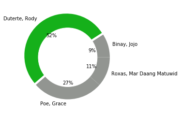

```python
# For comparison of distribution of candidates, lets compute provinces with literacy rate above and equal to 92% and
#dominance of president in those provinces by creating a donut plot:


x= [re.findall(r'(.*)[(W].*',i) for i in pres_above_lit.index.tolist()]
y = [item for sublist in x for item in sublist]
z = [i.title() for i in y]

plt.pie(pres_above_lit, labels = z,explode=(0,0.05,0,0),
        colors=['xkcd:grey','xkcd:green','xkcd:grey','xkcd:grey'],
       autopct='%1.0f%%')
# add a circle at the center
my_circle=plt.Circle( (0,0), 0.7, color='white')
p=plt.gcf()
p.gca().add_artist(my_circle)

plt.show()
```

### Percentage of provinces with literacy rate below 92% in terms of dominant candidate

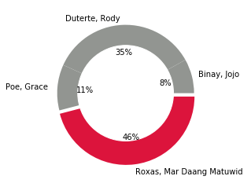

```python
# Below literacy rate of 92%


x= [re.findall(r'(.*)[(W].*',i) for i in pres_below_lit.index.tolist()]
y = [item for sublist in x for item in sublist]
z = [i.title() for i in y]

plt.pie(pres_below_lit, labels = z,explode=(0,0,0,0.05),
        colors=['xkcd:grey','xkcd:grey','xkcd:grey','crimson'],
       autopct='%1.0f%%')

# add a circle at the center
my_circle=plt.Circle( (0,0), 0.7, color='white')
p=plt.gcf()
p.gca().add_artist(my_circle)

plt.show()
```

[figure not shown]

**Mar Roxas came into politics not because he wanted to change the nation, but to continue the reign that was running in their hierarchy. Roxas’ entry to politics is a tale shared by many politicians, including his running mate Camarines Sur Representative Maria Leonor “Leni” Robredo. Roxas came back to the Philippines and ran for Congress, taking over the seat his younger brother left behind. Connecting the dots, he promised Filipinos in his campaigns, the cliche needs which is satisfactory for people below average literacy rate, assuming the fact that poverty is linked with lower literacy. However, Duterte on the other hand is a maverick, who doesn't hail the background of an elite family tree, have revolutionary plans for Philippines, viewed as a revolutionary by people lying above the average literacy rate. In our opinion, they see a bigger picture for Philippines. Duterte is a man, who can even take stand against China if it supports the development of the nation, eradicating the dependencies of other nation that help them more than it helps Philippines. Majority of the Philippines are above global literacy rate and hence it supports the argument why Duterte was elected back in 2016 for President.**

**In conclusion, Education gives us a knowledge of the world around us and changes it into something better.It helps us build opinions and have points of view on things in life. And moreover, it helps us create right biases and therefore, right decision in our lives. On a holistic level, the power of education also helps in selecting right leaders, that governs our nation**